**You may need to install [OpenCV](https://pypi.python.org/pypi/opencv-python) and [scikit-video](http://www.scikit-video.org/stable/).**

```python
import keras
import numpy as np
import io
import base64
from IPython.display import HTML
import skvideo.io
import cv2
import json

from keras.models import Sequential,model_from_json
from keras.layers.core import Dense
from keras.optimizers import sgd
from keras.layers import Flatten, Conv2D, MaxPooling2D, Activation, AveragePooling2D,Reshape,BatchNormalization
```

# MiniProject #3: Deep Reinforcement Learning

**Notations**: $E_p$ is the expectation under probability $p$. Please justify each of your answer and widely comment your code.

# Context

In a reinforcement learning algorithm, we modelize each step $t$ as an action $a_t$ obtained from a state $s_t$, i.e. $\{(a_{t},s_{t})_{t\leq T}\}$ having the Markov property. We consider a discount factor $\gamma \in [0,1]$ that ensures convergence. The goal is to find among all the policies $\pi$, one that maximizes the expected reward:

\begin{equation*} R(\pi)=\sum_{t\leq T}E_{p^{\pi}}[\gamma^t r(s_{t},a_{t})] \> , \end{equation*}

where: \begin{equation*}p^{\pi}(a_{0},a_{1},s_{1},...,a_{T},s_{T})=p(a_{0})\prod_{t=1}^{T}\pi(a_{t}|s_{t})p(s_{t+1}|s_{t},a_{t}) \> . \end{equation*}

We note the $Q$-function:

\begin{equation*}Q^\pi(s,a)=E_{p^{\pi}}[\sum_{t\leq T}\gamma^{t}r(s_{t},a_{t})|s_{0}=s,a_{0}=a] \> . \end{equation*}

Thus, the optimal Q function is: \begin{equation*} Q^*(s,a)=\max_{\pi}Q^\pi(s,a) \> . \end{equation*}

In this project, we will apply the deep reinforcement learning techniques to a simple game: an agent will have to learn from scratch a policy that will permit it maximizing a reward.

## The environment, the agent and the game

### The environment

`Environment` is an abstract class that represents the states, rewards, and actions to obtain the new state.

```python
class Environment(object):
    def __init__(self):
        pass

    def act(self, act):
        """
        One can act on the environment and obtain its reaction:
        - the new state
        - the reward of the new state
        - should we continue the game?

        :return: state, reward, game_over
        """
        pass


    def reset(self):
        """
        Reinitialize the environment to a random state and returns
        the original state

        :return: state
        """
        pass

    def draw(self):
        """
        Visualize in the console or graphically the current state
        """
        pass
```

The method `act` allows to act on the environment at a given state $s_t$ (stored internally), via action $a_t$. The method will return the new state $s_{t+1}$, the reward $r(s_{t},a_{t})$ and determines if $t\leq T$ (*game_over*).

The method `reset` simply reinitializes the environment to a random state $s_0$.

The method `draw` displays the current state $s_t$ (this is useful to check the behavior of the Agent).

We modelize $s_t$ as a tensor, while $a_t$ is an integer.

### The Agent

The goal of the `Agent` is to interact with the `Environment` by proposing actions $a_t$ obtained from a given state $s_t$ to attempt to maximize its **reward** $r(s_t,a_t)$. We propose the following abstract class:

```python
class Agent(object):
    def __init__(self, epsilon=0.1, n_action=4):
        self.epsilon = epsilon
        self.n_action = n_action

    def set_epsilon(self,e):
        self.epsilon = e

    def act(self,s,train=True):
        """ This function should return the next action to do:
        an integer between 0 and 4 (not included) with a random exploration of epsilon"""
        if train:
            if np.random.rand() <= self.epsilon:
                a = np.random.randint(0, self.n_action, size=1)[0]
            else:
                a = self.learned_act(s)
        else: # in some cases, this can improve the performance.. remove it if poor performances
            a = self.learned_act(s)

        return a

    def learned_act(self,s):
        """ Act via the policy of the agent, from a given state s
        it proposes an action a"""
        pass

    def reinforce(self, s, n_s, a, r, game_over_):
        """ This function is the core of the learning algorithm.
        It takes as an input the current state s_, the next state n_s_
        the action a_ used to move from s_ to n_s_ and the reward r_.

        Its goal is to learn a policy.
        """
        pass

    def save(self):
        """ This function returns basic stats if applicable: the
        loss and/or the model"""
        pass

    def load(self):
        """ This function allows to restore a model"""
        pass
```

**Question 1**: Explain the function act. Why is `epsilon` essential?

(you can use Markdown and Latex)

The function act takes in argument the current state and returns the action that we need to take. If we are in the phase of training (learning the policy), we need to explore the environnement in order to learn about new actions and improve the chances of getting future best reward, however we need also to maximize our action's reward. For this purpose, the ```epsilon``` is essential to control this compromise between exploration and exploitation, it's always chosen to be small to not get poor expected rewards. When we finish the phase of training, we have discovred enough the environment and then our only goal is to maximize the rewards, so there is no need for the ```epsilon``` which means no need for the exploration.

### The Game

The `Agent` and the `Environment` work in an interlaced way as in the following (take some time to understand this code as it is the core of the project)

```
epoch = 300
env = Environment()
agent = Agent()


# Number of won games
score = 0
loss = 0


for e in range(epoch):
    # At each epoch, we restart to a fresh game and get the initial state
    state = env.reset()
    # This assumes that the games will end
    game_over = False

    win = 0
    lose = 0

    while not game_over:
        # The agent performs an action
        action = agent.act(state)

        # Apply an action to the environment, get the next state, the reward
        # and if the games end
        prev_state = state
        state, reward, game_over = env.act(action)

        # Update the counters
        if reward > 0:
            win = win + reward
        if reward < 0:
            lose = lose -reward

        # Apply the reinforcement strategy
        loss = agent.reinforce(prev_state, state,  action, reward, game_over)

    # Save as a mp4
    if e % 10 == 0:
        env.draw(e)

    # Update stats
    score += win-lose

    print("Epoch {:03d}/{:03d} | Loss {:.4f} | Win/lose count {}/{} ({})"
          .format(e, epoch, loss, win, lose, win-lose))
    agent.save()
```

# The game, *eat cheese*

A rat runs on an island and tries to eat as much as possible. The island is subdivided into $N\times N$ cells, in which there are cheese (+0.5) and poisonous cells (-1). The rat has a visibility of 2 cells (thus it can see $5^2$ cells). The rat is given a time $T$ to accumulate as much food as possible. It can perform 4 actions: going up, down, left, right.

The goal is to code an agent to solve this task that will learn by trial and error. We propose the following environment:

```python
class Environment(object):
    def __init__(self, grid_size=10, max_time=500, temperature=0.1):
        grid_size = grid_size+4
        self.grid_size = grid_size
        self.max_time = max_time
        self.temperature = temperature

        #board on which one plays
        self.board = np.zeros((grid_size,grid_size))
        self.position = np.zeros((grid_size,grid_size))

        # coordinate of the cat
        self.x = 0
        self.y = 1

        # self time
        self.t = 0

        self.scale=16

        self.to_draw = np.zeros((max_time+2, grid_size*self.scale, grid_size*self.scale, 3))


    def draw(self,e):
        skvideo.io.vwrite(str(e) + '.mp4', self.to_draw)

    def get_frame(self,t):
        b = np.zeros((self.grid_size,self.grid_size,3))+128
        b[self.board>0,0] = 256
        b[self.board < 0, 2] = 256
        b[self.x,self.y,:]=256
        b[-2:,:,:]=0
        b[:,-2:,:]=0
        b[:2,:,:]=0
        b[:,:2,:]=0

        b =  cv2.resize(b, None, fx=self.scale, fy=self.scale, interpolation=cv2.INTER_NEAREST)

        self.to_draw[t,:,:,:]=b


    def act(self, action):
        #This function returns the new state, reward and decides if the
        #game ends.

        self.get_frame(int(self.t))

        self.position = np.zeros((self.grid_size, self.grid_size))

        self.position[0:2,:]= -1
        self.position[:,0:2] = -1
        self.position[-2:, :] = -1
        self.position[-2:, :] = -1

        self.position[self.x, self.y] = 1
        if action == 0:
            if self.x == self.grid_size-3:
                self.x = self.x-1
            else:
                self.x = self.x + 1
        elif action == 1:
            if self.x == 2:
                self.x = self.x+1
            else:
                self.x = self.x-1
        elif action == 2:
            if self.y == self.grid_size - 3:
                self.y = self.y - 1
            else:
                self.y = self.y + 1
        elif action == 3:
            if self.y == 2:
                self.y = self.y + 1
            else:
                self.y = self.y - 1
        else:
            RuntimeError('Error: action not recognized')

        self.t = self.t + 1
        reward = self.board[self.x, self.y]
        self.board[self.x, self.y] = 0
        game_over = self.t > self.max_time
        state = np.concatenate((self.board.reshape(self.grid_size, self.grid_size,1),
                        self.position.reshape(self.grid_size, self.grid_size,1)),axis=2)
        state = state[self.x-2:self.x+3,self.y-2:self.y+3,:]

        return state, reward, game_over

    def reset(self):
        """This function resets the game and returns the initial state"""

        self.x = np.random.randint(3, self.grid_size-3, size=1)[0]
        self.y = np.random.randint(3, self.grid_size-3, size=1)[0]


        bonus = 0.5*np.random.binomial(1,self.temperature,size=self.grid_size**2)
        bonus = bonus.reshape(self.grid_size,self.grid_size)

        malus = -1.0*np.random.binomial(1,self.temperature,size=self.grid_size**2)
        malus = malus.reshape(self.grid_size, self.grid_size)

        self.to_draw = np.zeros((self.max_time+2, self.grid_size*self.scale, self.grid_size*self.scale, 3))


        malus[bonus>0]=0

        self.board = bonus + malus

        self.position = np.zeros((self.grid_size, self.grid_size))
        self.position[0:2,:]= -1
        self.position[:,0:2] = -1
        self.position[-2:, :] = -1
        self.position[-2:, :] = -1
        self.board[self.x,self.y] = 0
        self.t = 0

        state = np.concatenate((
                               self.board.reshape(self.grid_size, self.grid_size,1),
                        self.position.reshape(self.grid_size, self.grid_size,1)),axis=2)

        state = state[self.x - 2:self.x + 3, self.y - 2:self.y + 3, :]
        return state
```

The following elements are important because they correspond to the hyper parameters for this project:

```python
# parameters
size = 13
T=200
temperature=0.3
epochs_train=20 # set small when debugging
epochs_test=20 # set small when debugging

# display videos
def display_videos(name):
    video = io.open(name, 'r+b').read()
    encoded = base64.b64encode(video)
    return '''<video alt="test" controls>
                <source src="data:video/mp4;base64,{0}" type="video/mp4" />
             </video>'''.format(encoded.decode('ascii'))
```

**Question 2** Explain the use of the arrays `position` and `board`.

The array ```board``` is the table that holds the rewards of every cell, when the rat is on a cell at time t, it's given the reward of this cell and this cell is put equal to 0 (since the rat has taken the reward which is either cheese, poisonous or nothing).

## Random Agent

**Question 3** Implement a random Agent (only `learned_act` needs to be implemented):

```python
class RandomAgent():
    def __init__(self):
        super(RandomAgent, self).__init__()
        pass

    def learned_act(self, s):
        return np.random.randint(3)
```

**Question 4** Visualize the game moves. You need to fill in the following function for the evaluation:

```python
def test(agent,env,epochs,prefix=''):
    # Number of won games
    score = 0

    for e in range(epochs):

        ##### FILL IN HERE
        state = env.reset()
        game_over = False
        win = 0
        lose = 0
        while not game_over:
            action = agent.learned_act(state)

            prev_state = state
            state, reward, game_over = env.act(action)

            if reward > 0:
                win = win + reward
            if reward < 0:
                lose = lose -reward

        # Save as a mp4
        env.draw(prefix+str(e))



        # Update stats
        score = score + win-lose

        print("Win/lose count {}/{}. Average score ({})"
              .format(win, lose, score/(1+e)))
    print('Final score: '+str(score/epochs))
    #return score/epochs
```

```python
# Initialize the game
env = Environment(grid_size=size, max_time=T,temperature=temperature)

# Initialize the agent!
agent = RandomAgent()

test(agent,env,epochs_test,prefix='random')
HTML(display_videos('random0.mp4'))
```

```
Win/lose count 7.0/7.0. Average score (0.0)
Win/lose count 4.0/6.0. Average score (-1.0)
Win/lose count 7.5/6.0. Average score (-0.16666666666666666)
Win/lose count 6.5/6.0. Average score (0.0)
Win/lose count 6.5/6.0. Average score (0.1)
Win/lose count 6.5/8.0. Average score (-0.16666666666666666)
Win/lose count 5.5/10.0. Average score (-0.7857142857142857)
Win/lose count 5.0/9.0. Average score (-1.1875)
Win/lose count 2.0/5.0. Average score (-1.3888888888888888)
Win/lose count 2.5/4.0. Average score (-1.4)
Win/lose count 7.5/9.0. Average score (-1.4090909090909092)
Win/lose count 4.0/7.0. Average score (-1.5416666666666667)
Win/lose count 2.5/3.0. Average score (-1.4615384615384615)
Win/lose count 2.0/1.0. Average score (-1.2857142857142858)
Win/lose count 6.0/12.0. Average score (-1.6)
Win/lose count 4.5/10.0. Average score (-1.84375)
Win/lose count 8.0/5.0. Average score (-1.5588235294117647)
Win/lose count 2.0/6.0. Average score (-1.6944444444444444)
Win/lose count 5.0/4.0. Average score (-1.5526315789473684)
Win/lose count 6.0/10.0. Average score (-1.675)
Final score: -1.675
```

[video not shown]

We get a negative final score, this was expected since we are choosing action randomly (we don't train a policy)

## DQN

Let us assume here that $T=\infty$.

**Question 5** Let $\pi$ be a policy, show that:

\begin{equation*} Q^{\pi}(s,a)=E_{(s',a')\sim p(.|s,a)}[r(s,a)+\gamma Q^{\pi}(s',a')] \end{equation*}

Then, show that for the optimal policy $\pi^*$ (we assume its existence), the following holds:

\begin{equation*} Q^{*}(s,a)=E_{s'\sim \pi^*(.|s,a)}[r(s,a)+\gamma\max_{a'}Q^{*}(s',a')]. \end{equation*} Finally, deduce that a plausible objective is:

\begin{equation*} \mathcal{L}(\theta)=E_{s' \sim \pi^*(.|s,a)}\Vert r+\gamma\max\max_{a'}Q(s',a',\theta)-Q(s,a,\theta)\Vert^{2}. \end{equation*}

1) If $T=\infty$, we can write :

\begin{equation*} \sum_{t=0}^{\infty}\gamma^{t}r(s_{t},a_{t}) = r(s_{0},a_{0}) + \sum_{t=1}^{\infty}\gamma^{t}r(s_{t},a_{t}) = r(s_{0},a_{0}) + \gamma\sum_{t=0}^{\infty}\gamma^{t}r(s_{t+1},a_{t+1}) \> . \end{equation*} Then: \begin{equation*}E_{p^{\pi}}[\sum_{t=0}^{\infty}\gamma^{t}r(s_{t},a_{t})|s_{0}=s,a_{0}=a] = E_{p^{\pi}}[r(s_{0},a_{0}) + \gamma\sum_{t=0}^{\infty}\gamma^{t}r(s_{t+1},a_{t+1}) |s_{0}=s,a_{0}=a] = E_{p^{\pi}}[r(s,a) + \gamma\sum_{t=0}^{\infty}\gamma^{t}r(s_{t+1},a_{t+1}) |s_{0}=s,a_{0}=a] = r(s,a) + \gamma E_{p^{\pi}}[\sum_{t=0}^{\infty}\gamma^{t}r(s_{t+1},a_{t+1}) |s_{0}=s,a_{0}=a] \> . \end{equation*} \begin{equation*} E_{p^{\pi}}[\sum_{t=0}^{\infty}\gamma^{t}r(s_{t+1},a_{t+1}) |s_{0}=s,a_{0}=a] = \sum_{(s',a')}^{}p(s_{1}=s',a_{1}=a'|s_{0}=s,a_{0}=a)E_{p^{\pi}}[\sum_{t=0}^{\infty}\gamma^{t}r(s_{t+1},a_{t+1}) |s_{1}=s',a_{1}=a'] \end{equation*} Since: \begin{equation*} E_{p^{\pi}}[\sum_{t=0}^{\infty}\gamma^{t}r(s_{t+1},a_{t+1}) |s_{1}=s',a_{1}=a'] = Q^{\pi}(s',a') \end{equation*} Then: \begin{equation*} r(s,a) + \gamma E_{p^{\pi}}[\sum_{t=0}^{\infty}\gamma^{t}r(s_{t+1},a_{t+1}) |s_{0}=s,a_{0}=a] = r(s,a) + \gamma E_{(s',a')\sim p(.|s,a)}[Q^{\pi}(s',a')] = E_{(s',a')\sim p(.|s,a)}[r(s,a)+\gamma Q^{\pi}(s',a')] \end{equation*} Finally: \begin{equation*} Q^{\pi}(s,a)=E_{(s',a')\sim p(.|s,a)}[r(s,a)+\gamma Q^{\pi}(s',a')] \end{equation*}

2) Since: \begin{equation*} Q^*(s,a)=\max_{\pi}Q^\pi(s,a) \> \end{equation*} Then: \begin{equation*} Q^*(s,a)=\max_{\pi}Q^\pi(s,a)=\max_{\pi}E_{(s',a')\sim p(.|s,a)}[r(s,a)+\gamma Q^{\pi}(s',a')] \> \end{equation*} And: \begin{equation*} Q^*(s,a)=\max_{\pi}\sum_{(s',a')}^{}p(s_{1}=s',a_{1}=a'|s_{0}=s,a_{0}=a)(r(s,a)+\gamma Q^{\pi}(s',a')) \> \end{equation*}

The DQN-learning algorithm relies on these derivations to train the parameters $\theta$ of a Deep Neural Network:

1. At the state $s_t$, select the action $a_t$ with best reward using $Q_t$ and store the results;
2. Obtain the new state $s_{t+1}$ from the environment $p$;
3. Store $(s_t,a_t,s_{t+1})$;
4. Obtain $Q_{t+1}$ by minimizing $\mathcal{L}$ from a recovered batch from the previously stored results.

**Question 6** Implement the class `Memory` that stores moves (in a replay buffer) via `remember` and provides a `random_access` to these. Specify a maximum memory size to avoid side effects. You can for example use a `list()` and set by default `max_memory=100`.

```python
class Memory(object):
    def __init__(self, max_memory=100):
        self.max_memory = max_memory
        self.memory = list()

    def remember(self, m):
        if len(self.memory)<100:
            self.memory.append(m)
        else:
            self.memory.pop(0)
            self.memory.append(m)

    def random_access(self):
        index = np.random.randint(len(self.memory))
        return self.memory[index]
```

The pipeline we will use for training is given below:

```python
def train(agent,env,epoch,prefix=''):
    # Number of won games
    score = 0
    loss = 0

    for e in range(epoch):
        # At each epoch, we restart to a fresh game and get the initial state
        state = env.reset()
        # This assumes that the games will terminate
        game_over = False

        win = 0
        lose = 0

        while not game_over:
            # The agent performs an action
            action = agent.act(state)

            # Apply an action to the environment, get the next state, the reward
            # and if the games end
            prev_state = state
            state, reward, game_over = env.act(action)

            # Update the counters
            if reward > 0:
                win = win + reward
            if reward < 0:
                lose = lose -reward

            # Apply the reinforcement strategy
            loss = agent.reinforce(prev_state, state,  action, reward, game_over)

        # Save as a mp4
        if e % 10 == 0:
            env.draw(prefix+str(e))

        # Update stats
        score += win-lose

        print("Epoch {:03d}/{:03d} | Loss {:.4f} | Win/lose count {}/{} ({})"
              .format(e, epoch, loss, win, lose, win-lose))
        agent.save(name_weights=prefix+'model.h5',name_model=prefix+'model.json')
```

**Question 7** Implement the DQN training algorithm using a cascade of fully connected layers. You can use different learning rate, batch size or memory size parameters. In particular, the loss might oscillate while the player will start to win the games. You have to find a good criterium.

```python
class DQN(Agent):
    def __init__(self, grid_size,  epsilon = 0.1, memory_size=100, batch_size = 16,n_state=2):
        super(DQN, self).__init__(epsilon = epsilon)

        # Discount for Q learning
        self.discount = 0.99

        self.grid_size = grid_size

        # number of state
        self.n_state = n_state

        # Memory
        self.memory = Memory(memory_size)

        # Batch size when learning
        self.batch_size = batch_size

    def learned_act(self, s):
        s = s.reshape(1,5,5,self.n_state)
        return np.argmax(self.model.predict(s))

    def reinforce(self, s_, n_s_, a_, r_, game_over_):
        # Two steps: first memorize the states, second learn from the pool

        self.memory.remember([s_, n_s_, a_, r_, game_over_])

        input_states = np.zeros((self.batch_size, 5,5,self.n_state))
        target_q = np.zeros((self.batch_size, 4))

        for i in range(self.batch_size):
            ######## FILL IN
            s_, n_s_, a_, r_, game_over_ = self.memory.random_access()
            input_states[i] = s_
            if game_over_:
                ######## FILL IN
                target_q[i,int(a_)] = r_
            else:
                ######## FILL IN
                n_s_ = n_s_.reshape(1,5,5,self.n_state)
                target_q[i,int(a_)] = r_ + self.discount*np.max(self.model.predict(n_s_))
        ######## FILL IN
        # HINT: Clip the target to avoid exploiding gradients.. -- clipping is a bit tighter
        target_q = np.clip(target_q, -3, 3)

        l = self.model.train_on_batch(input_states, target_q)


        return l

    def save(self,name_weights='model.h5',name_model='model.json'):
        self.model.save_weights(name_weights, overwrite=True)
        with open(name_model, "w") as outfile:
            json.dump(self.model.to_json(), outfile)

    def load(self,name_weights='model.h5',name_model='model.json'):
        with open(name_model, "r") as jfile:
            model = model_from_json(json.load(jfile))
        model.load_weights(name_weights)
        model.compile("sgd", "mse")
        self.model = model


class DQN_FC(DQN):
    def __init__(self, *args, lr=0.1,**kwargs):
        super(DQN_FC, self).__init__( *args,**kwargs)

        # NN Model

        ####### FILL IN
        model = Sequential()
        model.add(Dense(units=64, activation='relu', input_shape=(5,5,self.n_state)))
        model.add(Flatten())
        model.add(Dense(units=32, activation='relu'))
        model.add(Dense(units=4, activation='linear'))
        # Linear Output Layer as we are estimating a Function Q[S,A]

        model.compile(loss='mse', optimizer='adam')

        model.compile(sgd(lr=lr, decay=1e-4, momentum=0.0), "mse")
        self.model = model
```

```python
env = Environment(grid_size=size, max_time=T, temperature=0.3)
agent = DQN_FC(size, lr=.1, epsilon = 0.1, memory_size=2000, batch_size = 32)
train(agent, env, epochs_train, prefix='fc_train')
HTML(display_videos('fc_train10.mp4'))
```

```
WARNING:tensorflow:Variable *= will be deprecated. Use variable.assign_mul if you want assignment to the variable value or 'x = x * y' if you want a new python Tensor object.
```

[video not shown]

**Question 8** Implement the DQN training algorithm using a CNN (for example, 2 convolutional layers and one final fully connected layer).

```python
class DQN_CNN(DQN):
    def __init__(self, *args,lr=0.1,**kwargs):
        super(DQN_CNN, self).__init__(*args,**kwargs)

        ###### FILL IN
        model = Sequential()
        model.add(Conv2D(64, (3, 3), activation='relu',input_shape=(5, 5, self.n_state)))
        model.add(Conv2D(32, (3, 3), activation='relu'))
        #model.add(AveragePooling2D(pool_size=(2, 2), strides=None, padding='valid', data_format=None))
        model.add(Flatten())
        model.add(Dense(units=4, activation='linear'))
        model.compile(sgd(lr=lr, decay=1e-4, momentum=0.0), "mse")
        self.model = model
```

```python
env = Environment(grid_size=size, max_time=T, temperature=0.3)
agent = DQN_CNN(size, lr=.1, epsilon = 0.1, memory_size=2000, batch_size = 32)
train(agent,env,epochs_train,prefix='cnn_train')
HTML(display_videos('cnn_train10.mp4'))
```

[video not shown]

**Question 9** Test both algorithms and compare their performances. Which issue(s) do you observe? Observe also different behaviors by changing the temperature.

```python
env = Environment(grid_size=size, max_time=T,temperature=0.3)
agent_cnn = DQN_CNN(size, lr=.1, epsilon = 0.1, memory_size=2000, batch_size = 32)
agent_cnn.load(name_weights='cnn_trainmodel.h5',name_model='cnn_trainmodel.json')

agent_fc = DQN_FC(size, lr=.1, epsilon = 0.1, memory_size=2000, batch_size = 32)
agent_cnn.load(name_weights='fc_trainmodel.h5',name_model='fc_trainmodel.json')
print('Test of the CNN')
test(agent_cnn,env,epochs_test,prefix='cnn_test')
print('Test of the FC')
test(agent_fc,env,epochs_test,prefix='fc_test')
```

```
Test of the CNN
Win/lose count 4.5/1.0. Average score (3.5)
Win/lose count 2.0/0. Average score (2.75)
Win/lose count 1.5/0. Average score (2.3333333333333335)
Win/lose count 3.0/2.0. Average score (2.0)
Win/lose count 1.0/0. Average score (1.8)
Win/lose count 2.5/1.0. Average score (1.75)
Win/lose count 1.5/0. Average score (1.7142857142857142)
Win/lose count 2.0/0. Average score (1.75)
Win/lose count 3.0/2.0. Average score (1.6666666666666667)
Win/lose count 5.0/1.0. Average score (1.9)
Win/lose count 2.5/0. Average score (1.9545454545454546)
Win/lose count 5.0/1.0. Average score (2.125)
Win/lose count 3.0/0. Average score (2.1923076923076925)
Win/lose count 3.5/0. Average score (2.2857142857142856)
Win/lose count 0/0. Average score (2.1333333333333333)
Win/lose count 1.5/1.0. Average score (2.03125)
Win/lose count 1.0/0. Average score (1.9705882352941178)
Win/lose count 2.0/0. Average score (1.9722222222222223)
Win/lose count 4.0/0. Average score (2.0789473684210527)
Win/lose count 3.5/1.0. Average score (2.1)
Final score: 2.1
Test of the FC
Win/lose count 2.0/0. Average score (2.0)
Win/lose count 1.5/5.0. Average score (-0.75)
Win/lose count 0/0. Average score (-0.5)
Win/lose count 2.5/4.0. Average score (-0.75)
Win/lose count 0.5/3.0. Average score (-1.1)
Win/lose count 2.0/1.0. Average score (-0.75)
Win/lose count 2.5/3.0. Average score (-0.7142857142857143)
Win/lose count 2.0/0. Average score (-0.375)
Win/lose count 0.5/0. Average score (-0.2777777777777778)
Win/lose count 1.0/0. Average score (-0.15)
Win/lose count 0/1.0. Average score (-0.22727272727272727)
Win/lose count 2.0/1.0. Average score (-0.125)
Win/lose count 1.5/2.0. Average score (-0.15384615384615385)
Win/lose count 2.5/3.0. Average score (-0.17857142857142858)
Win/lose count 0.5/1.0. Average score (-0.2)
Win/lose count 1.0/3.0. Average score (-0.3125)
Win/lose count 0.5/1.0. Average score (-0.3235294117647059)
Win/lose count 1.5/1.0. Average score (-0.2777777777777778)
Win/lose count 1.5/1.0. Average score (-0.23684210526315788)
Win/lose count 1.5/1.0. Average score (-0.2)
Final score: -0.2
```

Temperature = 0.1

```python
env = Environment(grid_size=size, max_time=T,temperature=0.1)
agent_cnn = DQN_CNN(size, lr=.1, epsilon = 0.1, memory_size=2000, batch_size = 32)
agent_cnn.load(name_weights='cnn_trainmodel.h5',name_model='cnn_trainmodel.json')

agent_fc = DQN_FC(size, lr=.1, epsilon = 0.1, memory_size=2000, batch_size = 32)
agent_cnn.load(name_weights='fc_trainmodel.h5',name_model='fc_trainmodel.json')
print('Test of the CNN')
test(agent_cnn,env,epochs_test,prefix='cnn_test')
print('Test of the FC')
test(agent_fc,env,epochs_test,prefix='fc_test')
```

```
Test of the CNN
Win/lose count 1.5/0. Average score (1.5)
Win/lose count 0.5/0. Average score (1.0)
Win/lose count 2.5/0. Average score (1.5)
Win/lose count 1.5/0. Average score (1.5)
Win/lose count 0.5/0. Average score (1.3)
Win/lose count 0.5/0. Average score (1.1666666666666667)
Win/lose count 0.5/0. Average score (1.0714285714285714)
Win/lose count 0/0. Average score (0.9375)
Win/lose count 1.5/0. Average score (1.0)
Win/lose count 2.5/0. Average score (1.15)
Win/lose count 1.0/0. Average score (1.1363636363636365)
Win/lose count 1.0/0. Average score (1.125)
Win/lose count 0/0. Average score (1.0384615384615385)
Win/lose count 1.0/0. Average score (1.0357142857142858)
Win/lose count 1.0/0. Average score (1.0333333333333334)
Win/lose count 2.5/0. Average score (1.125)
Win/lose count 0/0. Average score (1.0588235294117647)
Win/lose count 0.5/0. Average score (1.0277777777777777)
Win/lose count 2.0/0. Average score (1.0789473684210527)
Win/lose count 0.5/0. Average score (1.05)
Final score: 1.05
Test of the FC
Win/lose count 2.0/0. Average score (2.0)
Win/lose count 0.5/0. Average score (1.25)
Win/lose count 0.5/0. Average score (1.0)
Win/lose count 0/0. Average score (0.75)
Win/lose count 0/0. Average score (0.6)
Win/lose count 0/0. Average score (0.5)
Win/lose count 0.5/3.0. Average score (0.07142857142857142)
Win/lose count 1.0/4.0. Average score (-0.3125)
Win/lose count 0/0. Average score (-0.2777777777777778)
Win/lose count 1.0/1.0. Average score (-0.25)
Win/lose count 0.5/1.0. Average score (-0.2727272727272727)
Win/lose count 0/1.0. Average score (-0.3333333333333333)
Win/lose count 0/0. Average score (-0.3076923076923077)
Win/lose count 2.0/1.0. Average score (-0.21428571428571427)
Win/lose count 0/0. Average score (-0.2)
Win/lose count 0.5/1.0. Average score (-0.21875)
Win/lose count 0.5/0. Average score (-0.17647058823529413)
Win/lose count 0/0. Average score (-0.16666666666666666)
Win/lose count 0.5/0. Average score (-0.13157894736842105)
Win/lose count 1.0/0. Average score (-0.075)
Final score: -0.075
```

By changing test function to return only the final score we can plot the final score vs temperature curve.

Temperature = 0.9

```python
env = Environment(grid_size=size, max_time=T,temperature=0.9)
agent_cnn = DQN_CNN(size, lr=.1, epsilon = 0.1, memory_size=2000, batch_size = 32)
agent_cnn.load(name_weights='cnn_trainmodel.h5',name_model='cnn_trainmodel.json')

agent_fc = DQN_FC(size, lr=.1, epsilon = 0.1, memory_size=2000, batch_size = 32)
agent_cnn.load(name_weights='fc_trainmodel.h5',name_model='fc_trainmodel.json')
print('Test of the CNN')
test(agent_cnn,env,epochs_test,prefix='cnn_test')
print('Test of the FC')
test(agent_fc,env,epochs_test,prefix='fc_test')
```

```
Test of the CNN
Win/lose count 11.0/0. Average score (11.0)
Win/lose count 16.5/2.0. Average score (12.75)
Win/lose count 11.0/0. Average score (12.166666666666666)
Win/lose count 16.0/0. Average score (13.125)
Win/lose count 13.0/1.0. Average score (12.9)
Win/lose count 12.5/2.0. Average score (12.5)
Win/lose count 3.0/1.0. Average score (11.0)
Win/lose count 8.5/1.0. Average score (10.5625)
Win/lose count 10.0/0. Average score (10.5)
Win/lose count 17.5/1.0. Average score (11.1)
Win/lose count 5.0/1.0. Average score (10.454545454545455)
Win/lose count 3.5/0. Average score (9.875)
Win/lose count 15.5/2.0. Average score (10.153846153846153)
Win/lose count 3.5/0. Average score (9.678571428571429)
Win/lose count 11.0/1.0. Average score (9.7)
Win/lose count 12.5/0. Average score (9.875)
Win/lose count 7.0/0. Average score (9.705882352941176)
Win/lose count 14.0/2.0. Average score (9.833333333333334)
Win/lose count 13.5/1.0. Average score (9.973684210526315)
Win/lose count 6.5/0. Average score (9.8)
Final score: 9.8
Test of the FC
Win/lose count 4.5/0. Average score (4.5)
Win/lose count 4.0/0. Average score (4.25)
Win/lose count 3.5/1.0. Average score (3.6666666666666665)
Win/lose count 3.5/1.0. Average score (3.375)
Win/lose count 1.5/0. Average score (3.0)
Win/lose count 2.0/0. Average score (2.8333333333333335)
Win/lose count 8.0/2.0. Average score (3.2857142857142856)
Win/lose count 4.0/1.0. Average score (3.25)
Win/lose count 2.5/0. Average score (3.1666666666666665)
Win/lose count 3.0/0. Average score (3.15)
Win/lose count 0.5/0. Average score (2.909090909090909)
Win/lose count 4.5/0. Average score (3.0416666666666665)
Win/lose count 6.5/1.0. Average score (3.230769230769231)
Win/lose count 5.0/1.0. Average score (3.2857142857142856)
Win/lose count 0.5/0. Average score (3.1)
Win/lose count 0.5/0. Average score (2.9375)
Win/lose count 1.0/0. Average score (2.823529411764706)
Win/lose count 7.0/2.0. Average score (2.9444444444444446)
Win/lose count 8.0/0. Average score (3.210526315789474)
Win/lose count 2.0/0. Average score (3.15)
Final score: 3.15
```

```python
Temperature = np.arange(0,1,0.1)
Score_cnn = []
Score_fc_test = []
for temp in Temperature:
    env = Environment(grid_size=size, max_time=T,temperature=0.1)
    agent_cnn = DQN_CNN(size, lr=.1, epsilon = 0.1, memory_size=2000, batch_size = 32)
    #agent_cnn.load(name_weights='cnn_trainmodel.h5',name_model='cnn_trainmodel.json')
    agent_fc = DQN_FC(size, lr=.1, epsilon = 0.1, memory_size=2000, batch_size = 32)
    #agent_cnn.load(name_weights='fc_trainmodel.h5',name_model='fc_trainmodel.json')
    #print('Test of the CNN')
    Score_cnn.append(test(agent_cnn,env,epochs_test,prefix='cnn_test'))
    #print('Test of the FC')
    Score_fc_test.append(test(agent_fc,env,epochs_test,prefix='fc_test'))
```

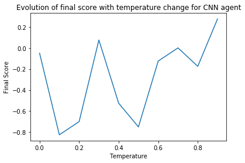

```python
import matplotlib.pyplot as plt
plt.figure(1)
plt.plot(Temperature,Score_cnn)
plt.xlabel('Temperature')
plt.ylabel('Final Score')
plt.title('Evolution of final score with temperature change for CNN agent')
plt.show()
```

[figure not shown]

```python
import matplotlib.pyplot as plt
plt.figure(1)
plt.plot(Temperature,Score_fc_test)
plt.xlabel('Temperature')
plt.ylabel('Final Score')
plt.title('Evolution of final score with temperature change for CNN agent')
plt.show()
```

```python
HTML(display_videos('cnn_test10.mp4'))
```

[video not shown]

```python
HTML(display_videos('fc_test10.mp4'))
```

[video not shown]

We can remark that we get sometimes a score of 0/0 which mean that we are going back to a cell that we have visited already. Also we can see that we don't explore different states (or cells). This could limit our reward since there could be some cell that have a large reward (as it can be very poor) that we have never took the action to visit them.

The algorithm tends to not explore the map which can be an issue. We propose two ideas in order to encourage exploration:

1. Incorporating a decreasing $\epsilon$-greedy exploration. You can use the method `set_epsilon`
2. Append via the environment a new state that describes if a cell has been visited or not

**Question 10** Design a new `train_explore` function and environment class `EnvironmentExploring` to tackle the issue of exploration.

```python
def train_explore(agent,env,epoch,prefix=''):
    # Number of won games
    score = 0
    loss = 0

    for e in range(epoch):
        # At each epoch, we restart to a fresh game and get the initial state
        state = env.reset()
        # This assumes that the games will terminate
        game_over = False

        win = 0
        lose = 0

        while not game_over:
            # The agent performs an action
            action = agent.act(state)

            # Apply an action to the environment, get the next state, the reward
            # and if the games end
            prev_state = state
            state, reward, game_over = env.act(action, train=True)

            # Update the counters
            if reward > 0:
                win = win + reward
            if reward < 0:
                lose = lose -reward

            # Apply the reinforcement strategy
            loss = agent.reinforce(prev_state, state,  action, reward, game_over)

        # Save as a mp4
        if e % 10 == 0:
            env.draw(prefix+str(e))

        # Update stats
        score += win-lose

        print("Epoch {:03d}/{:03d} | Loss {:.4f} | Win/lose count {}/{} ({})"
              .format(e, epoch, loss, win, lose, win-lose))
        agent.save(name_weights=prefix+'model.h5',name_model=prefix+'model.json')

class EnvironmentExploring(object):
    def __init__(self, grid_size=10, max_time=500, temperature=0.1):
        grid_size = grid_size+4
        self.grid_size = grid_size
        self.max_time = max_time
        self.temperature = temperature

        #board on which one plays
        self.board = np.zeros((grid_size,grid_size))
        self.position = np.zeros((grid_size,grid_size))
        self.malus_position = np.zeros((grid_size,grid_size))

        # coordinate of the cat
        self.x = 0
        self.y = 1

        # self time
        self.t = 0

        self.scale=16

        self.to_draw = np.zeros((max_time+2, grid_size*self.scale, grid_size*self.scale, 3))


    def draw(self,e):
        skvideo.io.vwrite(str(e) + '.mp4', self.to_draw)

    def get_frame(self,t):
        b = np.zeros((self.grid_size,self.grid_size,3))+128
        b[self.board>0,0] = 256
        b[self.board < 0, 2] = 256
        b[self.x,self.y,:]=256
        b[-2:,:,:]=0
        b[:,-2:,:]=0
        b[:2,:,:]=0
        b[:,:2,:]=0

        b =  cv2.resize(b, None, fx=self.scale, fy=self.scale, interpolation=cv2.INTER_NEAREST)

        self.to_draw[t,:,:,:]=b


    def act(self, action, train = False):
        #This function returns the new state, reward and decides if the
        #game ends.

        self.get_frame(int(self.t))

        self.position = np.zeros((self.grid_size, self.grid_size))

        self.position[0:2,:]= -1
        self.position[:,0:2] = -1
        self.position[-2:, :] = -1
        self.position[-2:, :] = -1

        self.position[self.x, self.y] = 1
        if action == 0:
            if self.x == self.grid_size-3:
                self.x = self.x-1
            else:
                self.x = self.x + 1
        elif action == 1:
            if self.x == 2:
                self.x = self.x+1
            else:
                self.x = self.x-1
        elif action == 2:
            if self.y == self.grid_size - 3:
                self.y = self.y - 1
            else:
                self.y = self.y + 1
        elif action == 3:
            if self.y == 2:
                self.y = self.y + 1
            else:
                self.y = self.y - 1
        else:
            RuntimeError('Error: action not recognized')
        reward = 0
        if train:
            reward = -self.malus_position[self.x, self.y]
        self.malus_position[self.x, self.y] = 0.1

        reward = reward + self.board[self.x, self.y]
        # 3 "feature" states instead of 2
        state = np.concatenate((self.malus_position.reshape(self.grid_size, self.grid_size,1),\
                                self.board.reshape(self.grid_size, self.grid_size,1),\
                        self.position.reshape(self.grid_size, self.grid_size,1)),axis=2)
        self.t = self.t + 1
        self.board[self.x, self.y] = 0
        game_over = self.t > self.max_time
        state = state[self.x-2:self.x+3,self.y-2:self.y+3,:]

        return state, reward, game_over

    def reset(self):
        #This function resets the game and returns the initial state

        self.x = np.random.randint(3, self.grid_size-3, size=1)[0]
        self.y = np.random.randint(3, self.grid_size-3, size=1)[0]


        bonus = 0.5*np.random.binomial(1,self.temperature,size=self.grid_size**2)
        bonus = bonus.reshape(self.grid_size,self.grid_size)

        malus = -1.0*np.random.binomial(1,self.temperature,size=self.grid_size**2)
        malus = malus.reshape(self.grid_size, self.grid_size)

        self.to_draw = np.zeros((self.max_time+2, self.grid_size*self.scale, self.grid_size*self.scale, 3))


        malus[bonus>0]=0

        self.board = bonus + malus

        self.position = np.zeros((self.grid_size, self.grid_size))
        self.position[0:2,:]= -1
        self.position[:,0:2] = -1
        self.position[-2:, :] = -1
        self.position[-2:, :] = -1
        self.board[self.x,self.y] = 0
        self.malus_position[self.x, self.y] = 0.1
        self.t = 0

        state = np.concatenate((self.malus_position.reshape(self.grid_size, self.grid_size,1),\
                                self.board.reshape(self.grid_size, self.grid_size,1),\
                        self.position.reshape(self.grid_size, self.grid_size,1)),axis=2)

        state = state[self.x - 2:self.x + 3, self.y - 2:self.y + 3, :]
        return state
```

```python
# Training
env = EnvironmentExploring(grid_size=size, max_time=T, temperature=0.3)
agent = DQN_CNN(size, lr=.1, epsilon = 0.1, memory_size=2000, batch_size = 32,n_state=3)
train_explore(agent, env, epochs_train, prefix='cnn_train_explore')
HTML(display_videos('cnn_train_explore10.mp4'))
```

[video not shown]

```python
# Evaluation
test(agent,env,epochs_test,prefix='cnn_test_explore')
HTML(display_videos('cnn_test_explore10.mp4'))
```

```
Win/lose count 1.0/0. Average score (1.0)
Win/lose count 3.0/0. Average score (2.0)
Win/lose count 2.5/0. Average score (2.1666666666666665)
Win/lose count 3.5/1.0. Average score (2.25)
Win/lose count 4.5/0. Average score (2.7)
Win/lose count 3.0/1.0. Average score (2.5833333333333335)
Win/lose count 2.5/0. Average score (2.5714285714285716)
Win/lose count 0/0. Average score (2.25)
Win/lose count 1.5/0. Average score (2.1666666666666665)
Win/lose count 6.5/0. Average score (2.6)
Win/lose count 6.0/0. Average score (2.909090909090909)
Win/lose count 7.0/0. Average score (3.25)
Win/lose count 8.5/2.0. Average score (3.5)
Win/lose count 2.5/0. Average score (3.4285714285714284)
Win/lose count 6.0/0. Average score (3.6)
Win/lose count 9.0/0. Average score (3.9375)
Win/lose count 9.0/0. Average score (4.235294117647059)
Win/lose count 10.0/0. Average score (4.555555555555555)
Win/lose count 5.5/2.0. Average score (4.5)
Win/lose count 4.0/0. Average score (4.475)
Final score: 4.475
```

[video not shown]

We can see here that almost all the actions taken gave a loss of 0 which will improve our final score. So doing an exploration in the training is increasing our performance.

**BONUS question** Use the expert DQN from the previous question to generate some winning games. Train a model that mimicks its behavior. Compare the performances.